[figure not shown]

# INF-393 Máquinas de Aprendizaje II-2019

### Tarea 1

**Temas**

- Problemas de clasificación y regresión.
- Regresión lineal ordinaria (mínimos cuadrados).
- Selección de atributos y parámetros de regularización en regresión lineal (Ridge y Lasso).
- Validación cruzada.
- Reducción de dimensionalidad: PCA e ICA.
- Selección de hiper-parámetros estructurales de modelos de aprendizaje.

*Estudiante:* Francisco Abarca Moraga  
*Rol:* 201673552-6  
*Email:* francisco.abarcamo@sansano.usm.cl

```python
import matplotlib.pyplot as plt
import pandas as pd
import seaborn as sns
import numpy as np
from scipy import stats as st
```

## Tratamiento de datos

Obtenemos los datos del dataset *heart.dat*, del cual modificaremos algunos valores para tener una comprensión mejor de sus elementos

```python
headers = ['age','sex','chest_pain','blood_p','serum','blood_s',
           'electro','max_heart', 'angina','oldpeak','slope',
           'vessel','thal','normal']
df = pd.read_csv("heart.dat",  header=None, names=headers, sep=' ')
# Categorizacion
pd.options.mode.chained_assignment = None  # default='warn'
df['sex'][df['sex'] == 0] = 'female'
df['sex'][df['sex'] == 1] = 'male'
df['chest_pain'][df['chest_pain'] == 1] = 'typical angina'
df['chest_pain'][df['chest_pain'] == 2] = 'atypical angina'
df['chest_pain'][df['chest_pain'] == 3] = 'non-anginal pain'
df['chest_pain'][df['chest_pain'] == 4] = 'asymptomatic'
df['blood_s'][df['blood_s'] == 0] = 'lower than 120mg/ml'
df['blood_s'][df['blood_s'] == 1] = 'greater than 120mg/ml'
df['electro'][df['electro'] == 0] = 'normal'
df['electro'][df['electro'] == 1] = 'ST-T wave abnormality'
df['electro'][df['electro'] == 2] = 'left ventricular hypertrophy'
df['angina'][df['angina'] == 0] = 'no'
df['angina'][df['angina'] == 1] = 'yes'
df['slope'][df['slope'] == 1] = 'upsloping'
df['slope'][df['slope'] == 2] = 'flat'
df['slope'][df['slope'] == 3] = 'downsloping'
df['thal'][df['thal'] == 3] = 'normal'
df['thal'][df['thal'] == 6] = 'fixed defect'
df['thal'][df['thal'] == 7] = 'reversable defect'
```

## Visualizacion de los datos

Primero veremos un par de entradas dentro del dataset para notar nuestras variables y de que tipo son

```python
df.head()
```

|  | age | sex | chest_pain | blood_p | serum | blood_s | electro | max_heart | angina | oldpeak | slope | vessel | thal | normal |
| --- | --- | --- | --- | --- | --- | --- | --- | --- | --- | --- | --- | --- | --- | --- |
| 0 | 70.0 | male | asymptomatic | 130.0 | 322.0 | lower than 120mg/ml | left ventricular hypertrophy | 109.0 | no | 2.4 | flat | 3.0 | normal | 2 |
| 1 | 67.0 | female | non-anginal pain | 115.0 | 564.0 | lower than 120mg/ml | left ventricular hypertrophy | 160.0 | no | 1.6 | flat | 0.0 | reversable defect | 1 |
| 2 | 57.0 | male | atypical angina | 124.0 | 261.0 | lower than 120mg/ml | normal | 141.0 | no | 0.3 | upsloping | 0.0 | reversable defect | 2 |
| 3 | 64.0 | male | asymptomatic | 128.0 | 263.0 | lower than 120mg/ml | normal | 105.0 | yes | 0.2 | flat | 1.0 | reversable defect | 1 |
| 4 | 74.0 | female | atypical angina | 120.0 | 269.0 | lower than 120mg/ml | left ventricular hypertrophy | 121.0 | yes | 0.2 | upsloping | 1.0 | normal | 1 |

Además solicitamos la información del dataframe para saber de forma más exacta su contenido (del cual sabemos los tipos exactos de las variables, cuantas son y cuantas entradas totales tenemos)

```python
df.info(verbose=True)
```

```
<class 'pandas.core.frame.DataFrame'>
RangeIndex: 270 entries, 0 to 269
Data columns (total 14 columns):
age           270 non-null float64
sex           270 non-null object
chest_pain    270 non-null object
blood_p       270 non-null float64
serum         270 non-null float64
blood_s       270 non-null object
electro       270 non-null object
max_heart     270 non-null float64
angina        270 non-null object
oldpeak       270 non-null float64
slope         270 non-null object
vessel        270 non-null float64
thal          270 non-null object
normal        270 non-null int64
dtypes: float64(6), int64(1), object(7)
memory usage: 29.6+ KB
```

En resumen, nuestro dataframe tiene 14 elementos, donde el último es la variable que deseamos predecir

Dentro de las **variable reales** tenemos:

- **age**: Edad del individuo
- **blood_p**: Presión sanguínea en descanso
- **serum**: Colesterol sérico
- **max_heart**: Ritmo ardíaco máximo obtenido
- **oldpeak**: Depresión inducida por ejercicio en un electrocardiograma
- **vessel**: Número de vasos mayores (0-3) coloreados en procedimiento
- **normal**: Absencia (1) o presencia (2) de enfermedad relativa al corazón [Variable a predecir]

Dentro de las **variables ordenadas**:

- **slope**: Pendiente en el ejercicio realizado en el electrocardiograma

Dentro de las **variables binarias**:

- **sex**: Sexo del individuo
- **blood_s**: Si el azúcar en la sangre es mayor a 120mg/dl
- **angina**: Si hay angina (dolor localizado) producida por ejercicio

Dentro de las **variables nominales**:

- **electro**: Resultado del electricardiograma (0,1,2)
- **chest_pain**: Tipo de dolor en el pecho (4 tipos)
- **thal**: Indicador de talasemia (enfermedades hemolíticas), 3 = normal, 6 = defecto fijo, 7 = defecto reversible

A continuación obtenemos información sobre la distribución de las variables numéricas

```python
df.describe()
```

|  | age | blood_p | serum | max_heart | oldpeak | vessel | normal |
| --- | --- | --- | --- | --- | --- | --- | --- |
| count | 270.000000 | 270.000000 | 270.000000 | 270.000000 | 270.00000 | 270.000000 | 270.000000 |
| mean | 54.433333 | 131.344444 | 249.659259 | 149.677778 | 1.05000 | 0.670370 | 1.444444 |
| std | 9.109067 | 17.861608 | 51.686237 | 23.165717 | 1.14521 | 0.943896 | 0.497827 |
| min | 29.000000 | 94.000000 | 126.000000 | 71.000000 | 0.00000 | 0.000000 | 1.000000 |
| 25% | 48.000000 | 120.000000 | 213.000000 | 133.000000 | 0.00000 | 0.000000 | 1.000000 |
| 50% | 55.000000 | 130.000000 | 245.000000 | 153.500000 | 0.80000 | 0.000000 | 1.000000 |
| 75% | 61.000000 | 140.000000 | 280.000000 | 166.000000 | 1.60000 | 1.000000 | 2.000000 |
| max | 77.000000 | 200.000000 | 564.000000 | 202.000000 | 6.20000 | 3.000000 | 2.000000 |

Con esta tabla podemos ver los valores de las variables que tiene valores númericos y sus rangos, además de media y desviación estándar, a continuación evaluamos las variables con valores nominales

```python
df.describe(include=['object'])
```

|  | sex | chest_pain | blood_s | electro | angina | slope | thal |
| --- | --- | --- | --- | --- | --- | --- | --- |
| count | 270 | 270 | 270 | 270 | 270 | 270 | 270 |
| unique | 2 | 4 | 2 | 3 | 2 | 3 | 3 |
| top | male | asymptomatic | lower than 120mg/ml | left ventricular hypertrophy | no | upsloping | normal |
| freq | 183 | 129 | 230 | 137 | 181 | 130 | 152 |

Con esta tabla podemos ver los datos nominales representados, su frecuencia y cuantas categorías tiene cada variable

### Pacientes sanos y enfermos

Primero debemos obtener los conjuntos de pacientes enfermos y sanos, los cuales se identifican con la variable **normal**

```python
sanos = df[df['normal'] == 1]
enf = df[df['normal'] == 2]
```

#### Presión sanguínea, azúcar en la sangre y ritmo cardíaco entre pacientes sanos y enfermos

Con el gráfico de ayuda podemos notar que las personas enfermas tienden a tener la presión más elevada (desde 140 hacia arriba), en cuanto a la métrica de azúcar en la sangre no podemos concluir demasiado, y sobre el ritmo cardíaco podemos decir que, si este es elevado, es más probable que el paciente este sano

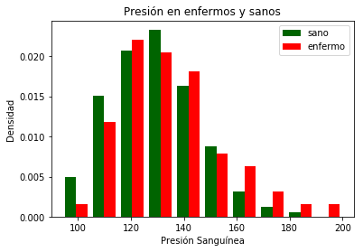

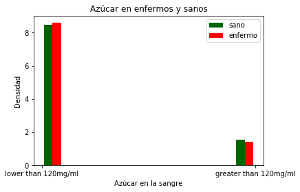

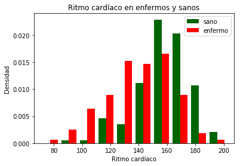

```python
p_s = list(sanos['blood_p'])
p_e = list(enf['blood_p'])
a_s = list(sanos['blood_s'])
a_e = list(enf['blood_s'])
r_s = list(sanos['max_heart'])
r_e = list(enf['max_heart'])
col = ["darkgreen","red"]
lab = ["sano","enfermo"]
plt.hist([p_s,p_e],color=col,label=lab,density=True)
plt.xlabel("Presión Sanguínea")
plt.ylabel("Densidad")
plt.title("Presión en enfermos y sanos")
plt.legend()
plt.show()
plt.hist([a_s,a_e],color=col,label=lab,density=True)
plt.xlabel("Azúcar en la sangre")
plt.ylabel("Densidad")
plt.title("Azúcar en enfermos y sanos")
plt.legend()
plt.show()
plt.hist([r_s,r_e],color=col,label=lab,density=True)
plt.xlabel("Ritmo cardíaco")
plt.ylabel("Densidad")
plt.title("Ritmo cardíaco en enfermos y sanos")
plt.legend()
plt.show()
```

### Diferencias de enfermedad entre los sexos y edades

Una métrica que puede ser importante, es el hecho del sexo del paciente, según nuestro gráfico la densidad de enfermos hombres es mucho mayor que las mujeres enfermas, en el caso de ser un paciente sano no podemos decir nada con certeza. En cuanto a la edad podemos notar que pasando la cifra de 50 años la cantidad de enfermos asciende de manera considerable, representando un buen indicador

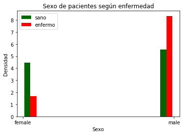

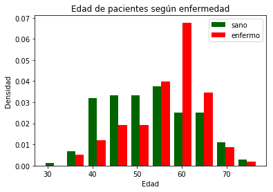

```python
p_s = list(sanos['sex'])
p_e = list(enf['sex'])
e_s = list(sanos['age'])
e_e = list(enf['age'])
col = ["darkgreen","red"]
lab = ["sano","enfermo"]
plt.hist([p_s,p_e],color=col,label=lab,density=True)
plt.xlabel("Sexo")
plt.ylabel("Densidad")
plt.title("Sexo de pacientes según enfermedad")
plt.legend()
plt.show()

plt.hist([e_s,e_e],color=col,label=lab,density=True)
plt.xlabel("Edad")
plt.ylabel("Densidad")
plt.title("Edad de pacientes según enfermedad")
plt.legend()
plt.show()
```

### Diferencias de enfermedad dada condición de talasemia

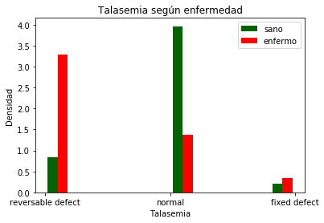

```python
p_s = list(sanos['thal'])
p_e = list(enf['thal'])
col = ["darkgreen","red"]
lab = ["sano","enfermo"]
plt.hist([p_s,p_e],color=col,label=lab,density=True)
plt.xlabel("Talasemia")
plt.ylabel("Densidad")
plt.title("Talasemia según enfermedad")
plt.legend()
plt.show()
```

## One hot encoding

En este proceso, nuestras variables categóricas las binarizamos, según la cantidad de valores nominales que pueda obtener esta variable, este es importante ya que los modelos pueden interpretar ciertos valores categóricos más importantes que otros afectando el resultado de los modelos. Al terminar nuestra binarización pasamos de 14 variables a 26

```python
df = pd.get_dummies(df)
df.head()
```

|  | age | blood_p | serum | max_heart | oldpeak | vessel | normal | sex_female | sex_male | chest_pain_asymptomatic | ... | electro_left ventricular hypertrophy | electro_normal | angina_no | angina_yes | slope_downsloping | slope_flat | slope_upsloping | thal_fixed defect | thal_normal | thal_reversable defect |
| --- | --- | --- | --- | --- | --- | --- | --- | --- | --- | --- | --- | --- | --- | --- | --- | --- | --- | --- | --- | --- | --- |
| 0 | 70.0 | 130.0 | 322.0 | 109.0 | 2.4 | 3.0 | 2 | 0 | 1 | 1 | ... | 1 | 0 | 1 | 0 | 0 | 1 | 0 | 0 | 1 | 0 |
| 1 | 67.0 | 115.0 | 564.0 | 160.0 | 1.6 | 0.0 | 1 | 1 | 0 | 0 | ... | 1 | 0 | 1 | 0 | 0 | 1 | 0 | 0 | 0 | 1 |
| 2 | 57.0 | 124.0 | 261.0 | 141.0 | 0.3 | 0.0 | 2 | 0 | 1 | 0 | ... | 0 | 1 | 1 | 0 | 0 | 0 | 1 | 0 | 0 | 1 |
| 3 | 64.0 | 128.0 | 263.0 | 105.0 | 0.2 | 1.0 | 1 | 0 | 1 | 1 | ... | 0 | 1 | 0 | 1 | 0 | 1 | 0 | 0 | 0 | 1 |
| 4 | 74.0 | 120.0 | 269.0 | 121.0 | 0.2 | 1.0 | 1 | 1 | 0 | 0 | ... | 1 | 0 | 0 | 1 | 0 | 0 | 1 | 0 | 1 | 0 |

5 rows × 26 columns

## Predicción de la presión sanguínea

Sabemos que una alta presión sanguínea es un buen indicador para estimar si el paciente posee una enfermedad, por ende intentaremos predecir la presión dada otras variables

### Preparación de los datos

Preparamos nuestro conjunto de datos para usar con el modelo de regresión lineal

```python
# Obtenemos nuestra etiqueta
label = df.pop("normal").values - 1
presion = df.pop("blood_p").values
X_data = df.values
```

### Creación conjunto de pruebas

Para tener datos con los cuales probar nuestro modelo y entrenarlo debemos generar un conjunto con el trabajar

```python
np.random.seed(0)
# Vector de seleccion 30%
mask_test = np.random.rand(X_data.shape[0]) < 0.30
# Selección de datos de entrenamiento y pruebas
X_train = X_data[~mask_test]
X_test = X_data[mask_test]
presion_train = presion[~mask_test]
presion_test = presion[mask_test]
label_train = label[~mask_test]
label_test = label[mask_test]
print("Entradas de entrenamiento:", X_train.shape[0])
print("Entradas de prueba:", X_test.shape[0])
```

```
Entradas de entrenamiento: 184
Entradas de prueba: 86
```

### Estandarización de los datos

Este paso es vital, ya que hace que nuestros datos sean consistentes y las comparaciones entre ellos sean relevantes

```python
from sklearn.preprocessing import StandardScaler
# Estandarizador
std = StandardScaler()
std.fit(X_train)
# Datos estandarizados
Xstd_train = std.transform(X_train)
Xstd_test = std.transform(X_test)
```

### Regresión lineal

Procedemos a ejecutar una regresión de mínimos cuadrados, con la cual buscamos predecir la presión sanguínea

```python
from sklearn.linear_model import LinearRegression
model = LinearRegression(fit_intercept=True)
model.fit(Xstd_train, presion_train)
pred_train = model.predict(Xstd_train)
pred_test = model.predict(Xstd_test)
```

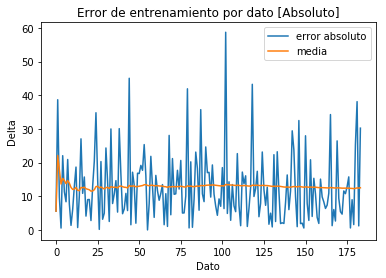

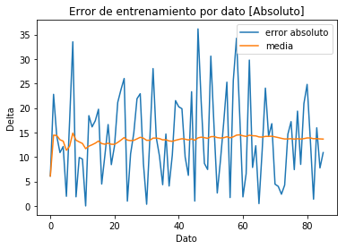

```python
# Grafico entrenamiento
def error(yhat,y):
    delta = yhat - y
    delta = list(map(abs,delta))
    i = 1
    sum = 0
    med = []
    for a in delta:
        sum += a
        med.append(sum/i)
        i += 1
    plt.plot(delta,label="error absoluto")
    plt.plot(med,label="media")
    plt.xlabel("Dato")
    plt.ylabel("Delta")
    plt.title("Error de entrenamiento por dato [Absoluto]")
    plt.legend()
    plt.show()

error(pred_train,presion_train)
error(pred_test,presion_test)
```

Con los graficos de error podemos notar que obtenemos un delta en la medicion de la presión sanguínea cercano a las 15 unidades (en ambos conjuntos), la cual es cercana a la desviación estándar del conjunto completo

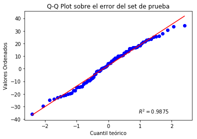

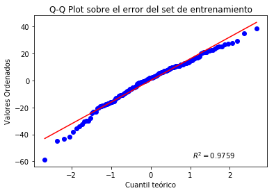

```python
error_train = pred_train - presion_train
error_test = pred_test - presion_test

grafico_1 = plt.figure()
eje_1 = grafico_1.add_subplot(111)
st.probplot(error_test, dist="norm", plot=eje_1, rvalue=True)
eje_1.set_title("Q-Q Plot sobre el error del set de prueba")
eje_1.set_xlabel("Cuantil teórico")
eje_1.set_ylabel("Valores Ordenados")
eje_1.set_title("Q-Q Plot sobre el error del set de prueba")


grafico_2 = plt.figure()
eje_2 = grafico_2.add_subplot(111)
st.probplot(error_train, dist="norm", plot=eje_2, rvalue=True)
eje_2.set_xlabel("Cuantil teórico")
eje_2.set_ylabel("Valores Ordenados")
eje_2.set_title("Q-Q Plot sobre el error del set de entrenamiento")

plt.show()
```

Revisando los gráficos Q-Q, podemos notar que las distribuciones tienen una tendencia a ser normales, con un desvío hacia los extremos

### Pesos y Z-score

Construiremos una tabla que representa los pesos finales del modelo, con su score, los cuales estan para cada variable del conjunto de datos

```python
variables = list(df.columns)
pesos = model.coef_
z_scores = []
for a in df.columns:
    z = st.zscore(df[a])
    z_scores.append(np.mean(z))

tabla = pd.DataFrame({"Variable":variables,"Peso":pesos,"Z-score":z_scores})
tabla.sort_values(by=["Peso"],ascending=False)
```

|  | Variable | Peso | Z-score |
| --- | --- | --- | --- |
| 0 | age | 3.703575 | 3.667848e-16 |
| 3 | oldpeak | 3.398092 | -5.263280e-17 |
| 1 | serum | 2.192226 | -2.467162e-16 |
| 13 | electro_ST-T wave abnormality | 2.150000 | -1.315820e-17 |
| 11 | blood_s_greater than 120mg/ml | 1.486991 | 4.194176e-17 |
| 18 | slope_downsloping | 1.286419 | 1.644775e-17 |
| 10 | chest_pain_typical angina | 1.146328 | 3.289550e-17 |
| 5 | sex_female | 1.069432 | -6.579099e-18 |
| 21 | thal_fixed defect | 1.023432 | 6.908054e-17 |
| 8 | chest_pain_atypical angina | 0.796765 | -1.973730e-17 |
| 23 | thal_reversable defect | 0.538830 | -3.289550e-17 |
| 14 | electro_left ventricular hypertrophy | 0.388525 | 7.401487e-18 |
| 20 | slope_upsloping | 0.337294 | 7.237009e-17 |
| 16 | angina_no | 0.142515 | -7.894919e-17 |
| 2 | max_heart | 0.081711 | 2.631640e-17 |
| 17 | angina_yes | -0.142515 | 7.894919e-17 |
| 7 | chest_pain_asymptomatic | -0.162102 | 0.000000e+00 |
| 15 | electro_normal | -0.835800 | 9.868649e-18 |
| 19 | slope_flat | -0.974878 | 3.125072e-17 |
| 22 | thal_normal | -1.034958 | -5.592234e-17 |
| 6 | sex_male | -1.069432 | 6.579099e-18 |
| 9 | chest_pain_non-anginal pain | -1.089938 | 1.578984e-16 |
| 12 | blood_s_lower than 120mg/ml | -1.486991 | -4.194176e-17 |
| 4 | vessel | -1.798951 | -6.579099e-17 |

Desde la tabla vemos que las variables mas influyentes son la edad, la depresión en el electrocardiograma y el colesterol

### Calidad de las predicciones

```python
from sklearn.metrics import mean_absolute_error, mean_squared_error
print("MSE train: ", mean_squared_error(presion_train, pred_train))
print("MSE test: ", mean_squared_error(presion_test, pred_test))
```

```
MSE train:  259.6292987777701
MSE test:  263.1851888628686
```

Notamos que el error de prueba es levemente mayor que el de entrenamiento

### Validación cruzada

Verificaremos la calidad del modelo mediante validación cruzada, el número de fold $K$ tomará dos valores $1$ (leave-one-out) y $5$

```
Error cuadrático medio con K=1: 337.5667677822604
Error cuadrático medio con K=5: 362.1008805407525
```

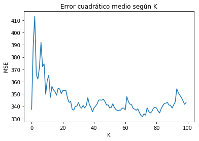

```python
from sklearn.model_selection import KFold
from sklearn.model_selection import LeaveOneOut

def cross_val(K=1):
    if K == 1:
        K = Xstd_train.shape[0]
        kf = KFold(n_splits=K)
    else:
        kf = KFold(n_splits=K)
    mse_cv = 0
    for train, val in kf.split(Xstd_train):
        linreg = LinearRegression(fit_intercept=True)
        linreg.fit(Xstd_train[train], presion_train[train])
        yhat_kfold_val = linreg.predict(Xstd_train[val])
        mse_fold =  np.mean(np.square(yhat_kfold_val - presion_train[val]))
        mse_cv += mse_fold
    mse_cv = mse_cv / K
    return mse_cv,linreg,yhat_kfold_val,val

error,_,_,_ = cross_val(1)
print("Error cuadrático medio con K=1:", error)
error,_,_,_ = cross_val(5)
print("Error cuadrático medio con K=5:", error)

error_l = list()
for a in range(100):
    error,_,_,_ = cross_val(a+1)
    error_l.append(error)

plt.plot(error_l)
plt.title("Error cuadrático medio según K")
plt.xlabel("K")
plt.ylabel("MSE")
plt.show()
```

### Ridge Regression

Regularizaremos los parametros segun una norma $l_2$

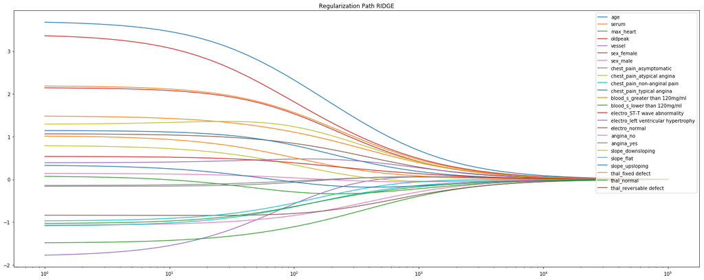

```python
from sklearn.linear_model import Ridge

def Ridge_Regression(df,X,Y, names_regressors=0,Flag=True):
    alphas_ = np.logspace(5,0, base=10)
    coefs = []
    model = Ridge(fit_intercept=True, solver='svd')
    for a in alphas_:
        model.set_params(alpha=a)
        model.fit(X, Y)
        coefs.append(model.coef_)
    if names_regressors == 0:
        names_regressors = df.columns
    plt.figure(figsize=(26,10))
    for y_arr, label in zip(np.squeeze(coefs).T, names_regressors):
        if label == "Dummy":
            plt.plot(alphas_, y_arr, label=label, color="k", ls=':')
        else:
            plt.plot(alphas_, y_arr, label=label)
    if Flag:
        plt.legend()
        plt.legend(loc='upper right')
    plt.title('Regularization Path RIDGE')
    plt.xscale('log')
    plt.show()

Ridge_Regression(df,Xstd_train,presion_train)
```

Con el gráfico podemos notar las convergencia de las variables lo cual demuestra que nuestras variables son colineares, lo cual nos dice que pierde sentido o importancia al buscar modelos más generales, aún así podemos rescatar algunas variables las cuales no convergen tan inmediatamente como la edad y la depresión ejercida por ejercicio en el electrocardiograma (oldpeak)

### Regresión Lasso

Ahora regularizaremos respecto a una norma $l_1$

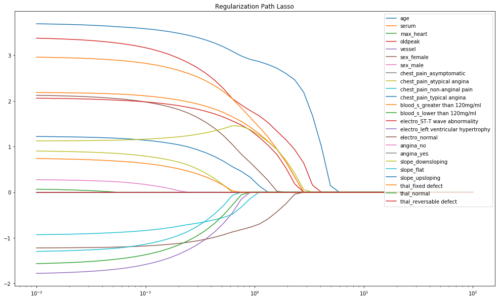

```python
from sklearn.linear_model import Lasso

def Lasso_Regression(df,X,Y,names_regressors=0,Flag=True):
    alphas_ = np.logspace(2,-2,base=10)
    coefs = []
    model = Lasso(fit_intercept=True)
    for a in alphas_:
        model.set_params(alpha=a)
        model.fit(X, Y)
        coefs.append(model.coef_)
    if names_regressors == 0:
        names_regressors = df.columns
    plt.figure(figsize=(17,10))
    for y_arr, label in zip(np.squeeze(coefs).T, names_regressors):
        if label == 'Dummy':
            plt.plot(alphas_, y_arr, label=label, color="k", ls=':')
        else:
            plt.plot(alphas_, y_arr, label=label)
    if Flag:
        plt.legend()
        plt.legend(loc='upper right')
    plt.xscale('log')
    plt.title('Regularization Path Lasso')
    plt.show()

Lasso_Regression(df,Xstd_train,presion_train)
```

En este gráfico es más evidente que el anterior las variables que son independientes, la más notoria siendo la edad del paciente. En cuanto a efectividad podemos notar que lasso es más evidente que ridge regression

### Calidad de regularizaciones

Veremos la calidad de lasso y regression ridge, además buscaremos un alfa para cada una que nos sea satisfactorio

```python
from ipywidgets import interactive
from sklearn.linear_model import Ridge
from sklearn.linear_model import Lasso

def train_model_Ridge(param):
    model = Ridge()
    A = 10**(param)
    print("Param alpha= ",A)
    model.set_params(alpha=A)
    model.fit(Xstd_train, presion_train)
    print("MSE train: ", mean_squared_error(presion_train, model.predict(Xstd_train) ))
    print("MSE test: ", mean_squared_error(presion_test, model.predict(Xstd_test) ))

def train_model_Lasso(param):
    model = Lasso()
    A = 10**(param)
    print("Param alpha= ",A)
    model.set_params(alpha=A)
    model.fit(Xstd_train, presion_train)
    print("MSE train: ", mean_squared_error(presion_train, model.predict(Xstd_train) ))
    print("MSE test: ", mean_squared_error(presion_test, model.predict(Xstd_test) ))

p_min = -10 #define your range
p_max = 10 #define your range
```

```python
print("Interactivo modelo Ridge")
interactive(train_model_Ridge, param=(p_min,p_max))
```

```
Interactivo modelo Ridge
```

```python
print("Interactivo modelo Lasso")
interactive(train_model_Lasso, param=(p_min,p_max))
```

```
Interactivo modelo Lasso
```

Nuestro alfa en Ridge no tiene mayor variación si es menor que $10$,en el caso de Lasso si el valor es mayor que $0.01$ este hace crecer el error rápidamente. Al final para Ridge usaremos un valor de alfa de $10$ y para Lasso de $0.01$

### Selección vía FSS

Implementaremos Forward Step-wise Selection donde seleccionaremos localmente características

```python
def fss(x, y, names_x, k = 10000):
    p = x.shape[1]-1
    k = min(p, k)
    names_x = np.array(names_x)
    remaining = list(range(0, p))
    selected = [p]
    current_score = best_new_score = 0.0
    errores = [[],[]]
    var = 1
    while remaining and len(selected)<=k :
        score_candidates = []
        for candidate in remaining:
            model = LinearRegression(fit_intercept=True, n_jobs=1)
            indexes = selected + [candidate]
            x_train = x[:,indexes]
            predictions_train = model.fit(x_train, y).predict(x_train)
            residuals_train =  predictions_train - y
            error_candidate =  np.mean(np.power(residuals_train, 2))
            errores[0].append(error_candidate)
            errores[1].append(x_train.shape[1])
            score_candidates.append((error_candidate, candidate))
        score_candidates.sort()
        score_candidates[:] = score_candidates[::-1]
        best_new_score, best_candidate = score_candidates.pop()
        remaining.remove(best_candidate)
        selected.append(best_candidate)
        var += 1
        # print("selected = %s ..." % names_x[best_candidate])
        # print("totalvars=%d, mse = %f" % (len(indexes),best_new_score))
    return selected, errores

features_fss,errores = fss(Xstd_train, presion_train, df.columns)
need_feat = features_fss[:5]
b = df.columns
print("Mejores 5 candidatos")
for a in need_feat:
    print("  - %s" % b[a])
_,errores_prueba = fss(Xstd_test, presion_test, df.columns)
```

```
Mejores 5 candidatos
  - thal_reversable defect
  - age
  - slope_downsloping
  - electro_ST-T wave abnormality
  - serum
```

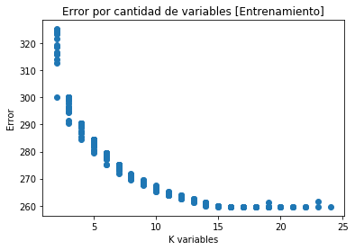

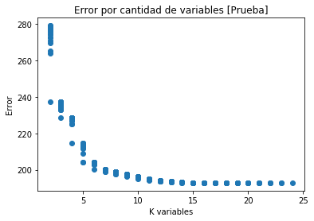

```python
plt.scatter(errores[1],errores[0])
plt.title("Error por cantidad de variables [Entrenamiento]")
plt.xlabel("K variables")
plt.ylabel("Error")
plt.show()
plt.scatter(errores_prueba[1],errores_prueba[0])
plt.title("Error por cantidad de variables [Prueba]")
plt.xlabel("K variables")
plt.ylabel("Error")
plt.show()
```

### Agregar atributos falsos

Agregaremos atributos falsos para ver como los distintos métodos de selección los filtran

```python
D = 50
F = np.random.normal(loc = 3, scale = 0.1, size=(Xstd_train.shape[0],D))
X_new_train= np.concatenate([Xstd_train, F], axis=-1)
F = np.random.normal(loc = 3, scale = 0.1, size=(Xstd_test.shape[0],D))
X_new_test= np.concatenate([Xstd_test, F], axis=-1)
```

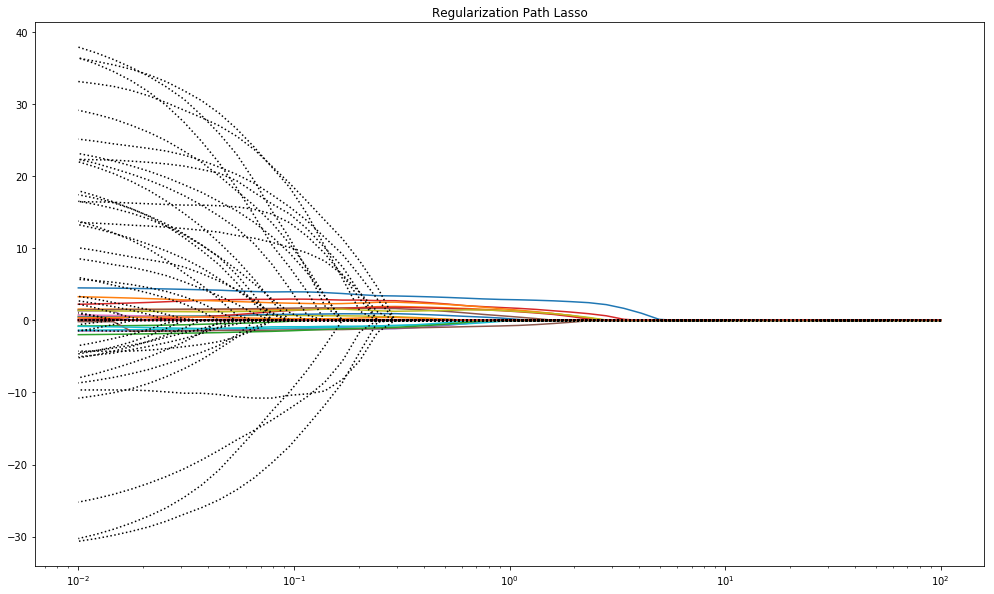

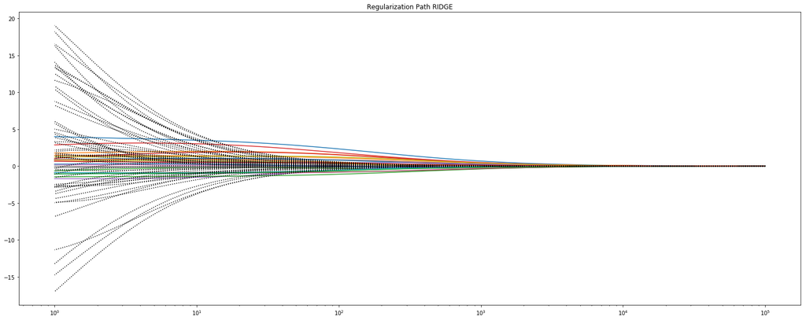

```python
names = list(df.columns)
for a in range(50):
    names.append('Dummy')

Lasso_Regression(X_new_train,X_new_train,presion_train,names,Flag=False)
Ridge_Regression(X_new_train,X_new_train,presion_train,names,Flag=False)
```

```
Mejores 5 candidatos [FSS]
  - Dummy
  - age
  - Dummy
  - slope_downsloping
  - Dummy
```

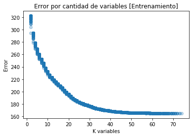

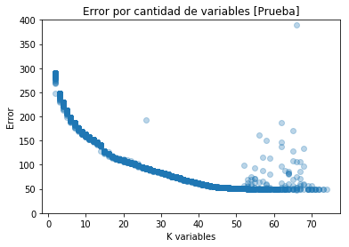

```python
features_fss,errores = fss(X_new_train, presion_train, names)
need_feat = features_fss[:5]

print("Mejores 5 candidatos [FSS]")
for a in need_feat:
    print("  - %s" % names[a])
_,errores_prueba = fss(X_new_test, presion_test, names)

plt.scatter(errores[1],errores[0],alpha=0.3)
plt.title("Error por cantidad de variables [Entrenamiento]")
plt.xlabel("K variables")
plt.ylabel("Error")
plt.show()
plt.scatter(errores_prueba[1],errores_prueba[0],alpha=0.3)
plt.title("Error por cantidad de variables [Prueba]")
plt.xlabel("K variables")
plt.ylabel("Error")
plt.ylim(0,400)
plt.show()
```

Si miramos nuestras gráficas podemos ver como las variables dummy (líneas punteadas negras) convergen antes que las variables originales, por ende, los modelos discriminan correctamente (Lasso y Ridge).

En cuanto a FSS, este tiende a disminuir su error de entrenamiento con mas variables, pero, el error de prueba aunque disminuye obtiene mucho ruido lo cual no es confiable, además de seleccionar variables dummy lo cual no es satisfactorio.

## Detectar una enfermedad

Con la información previa obtenida, deberemos hacer una predicción sobre la presencia de una enfermedad cardíaca, nos basaremos en que el comportamiento anormal de la presión sanguínea es un indicio de enfermedad

### Modelo predictor de presión sanguínea de pacientes sanos

Con esto obtendremos un modelo que será capaz de predecir la presión sanguínea de paciente los pacientes sanos

```python
mask_norm = label_train == 0

model = Lasso()
model.fit(Xstd_train[mask_norm], presion_train[mask_norm])

blood_p_tr = model.predict(Xstd_train)
blood_p_te = model.predict(Xstd_test)
```

### Clasificación de pacientes

Definiremos un umbral de decisión óptimo para poder separar correctamente los estados enfermo y sano, dada la presión sanguínea estimada por el modelo

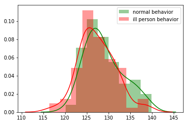

```python
import seaborn as sns
sns.distplot(blood_p_tr[mask_norm], label="normal behavior", color="green")
sns.distplot(blood_p_tr[~mask_norm], label="ill person behavior", color="red")
plt.legend()
plt.show()

def predict_umbr(data, umbral_up, umbral_low):
    preds = []
    for value in data:
        if value > umbral_up or value < umbral_low:
            preds.append(1) #presencia
        else:
            preds.append(0)
    return np.asarray(preds)

pred_train = predict_umbr(blood_p_tr, 140, 125)
pred_test = predict_umbr(blood_p_te, 140, 125)
```

### Calidad de la clasificación

Evaluaremos nuestro umbral a traves de la exactitud de ambos conjuntos

```python
from sklearn.metrics import accuracy_score
from ipywidgets import interact, IntSlider

def accuracy(inf,sup):
    pred_train = predict_umbr(blood_p_tr, sup, inf)
    pred_test = predict_umbr(blood_p_te, sup, inf)
    print("Score train: ", accuracy_score(label_train, pred_train))
    print("Score test: ", accuracy_score(label_test, pred_test))

print("Interactivo Score train/test")

inferior = IntSlider(min=110,max=150)
superior = IntSlider(min=110,max=150)
interact(accuracy, inf=inferior, sup=superior)
```

```
Interactivo Score train/test
```

```
<function __main__.accuracy(inf, sup)>
```

Usando el widget interactivo podemos notar que al reducir el límite inferior incrementamos la precisióny el caso contrario para el límite superior.

Ahora utilizaremos un modelo lineal simple de clasificación binaria como el perceptron

```python
from sklearn.linear_model import Perceptron

model = Perceptron(fit_intercept=True, eta0=1.0, max_iter=1000, n_jobs=-1, tol=1e-3)
model.fit(Xstd_train, label_train)
pred_train = model.predict(Xstd_train)
pred_test = model.predict(Xstd_test)
print("Score train: ",accuracy_score(label_train, pred_train))
print("Score test: ",accuracy_score(label_test, pred_test))
```

```
Score train:  0.7717391304347826
Score test:  0.7674418604651163
```

Al comparar ambos métodos notamos una gran ventaja en precisión por parte del perceptron, entre las diferencias esta el uso de un modelo lineal (lo cual impacta cuanto nos demoraremos en obtenerlo), la cantidad de datos para entrenar (en caso del perceptron este es dependiente de ellos, pero la clasificación inicial no)

### Reducción de dimensionalidad PCA

Para obtener una representación más visual sobre la clasificación de los datos realizaremos una proyección 2D de los datos

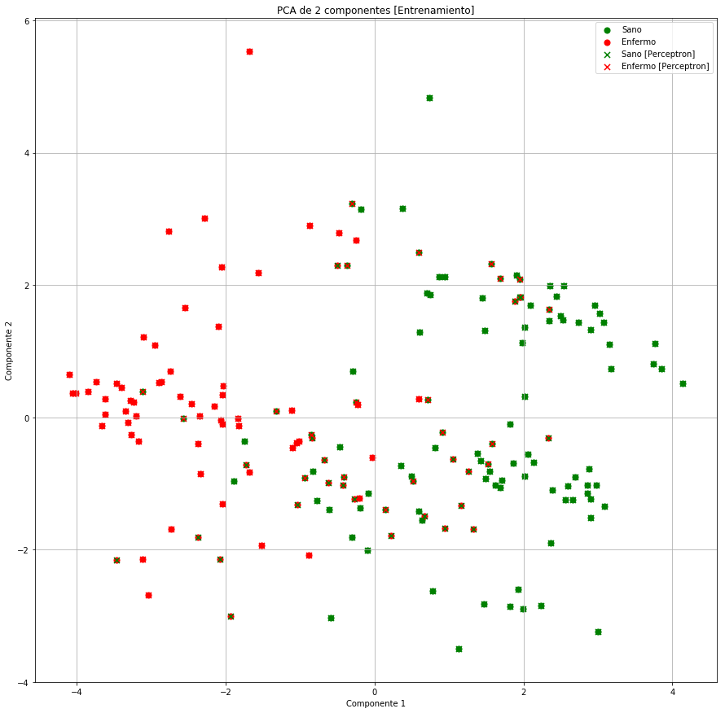

```python
from sklearn.decomposition import PCA
d = 2
pca_model = PCA(n_components=d)
pca_model.fit(Xstd_train)
X_pca_train = pca_model.transform(Xstd_train)
Entrenamiento = pd.DataFrame(data=X_pca_train,columns=['Componente 1','Componente 2'])
Entrenamiento_Final = pd.concat([Entrenamiento,pd.Series(label_train,name='Enfermo')],axis=1)
fig = plt.figure(figsize=(15,15))
ax = fig.add_subplot(1,1,1)

ax.set_xlabel("Componente 1")
ax.set_ylabel("Componente 2")
ax.set_title("PCA de 2 componentes [Entrenamiento]")
targets = [0,1]
colores = ['g','r']
for target, color in zip(targets,colores):
    indice = Entrenamiento_Final['Enfermo'] == target
    ax.scatter(Entrenamiento_Final.loc[indice, 'Componente 1']
               , Entrenamiento_Final.loc[indice, 'Componente 2']
              , c = color
              , s = 50)

Perceptron = pd.DataFrame(data=X_pca_train,columns=['Componente 1','Componente 2'])
Perceptron_Final = pd.concat([Entrenamiento,pd.Series(pred_train,name='Enfermo')],axis=1)
targets = [0,1]
colores = ['g','r']
for target, color in zip(targets,colores):
    indice = Perceptron_Final['Enfermo'] == target
    ax.scatter(Perceptron_Final.loc[indice, 'Componente 1']
               , Perceptron_Final.loc[indice, 'Componente 2']
              , c = color
              , s = 50
              ,marker = "x")
ax.legend(["Sano","Enfermo",'Sano [Perceptron]','Enfermo [Perceptron]'])
ax.grid()
plt.show()
varianza_PCA_train = pca_model.explained_variance_ratio_
ruido_PCA_train = pca_model.noise_variance_
```

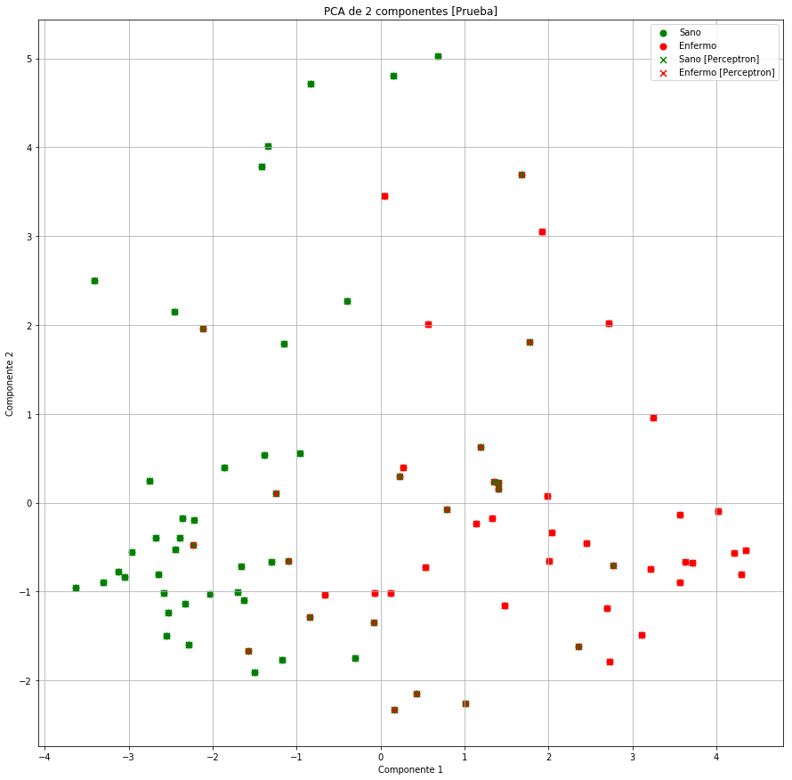

```python
d = 2
pca_model = PCA(n_components=d)
pca_model.fit(Xstd_test)
X_pca_test = pca_model.transform(Xstd_test)
Test = pd.DataFrame(data=X_pca_test,columns=['Componente 1','Componente 2'])
Test_Final = pd.concat([Test,pd.Series(label_test,name='Enfermo')],axis=1)
fig = plt.figure(figsize=(15,15))
ax = fig.add_subplot(1,1,1)
ax.set_xlabel("Componente 1")
ax.set_ylabel("Componente 2")
ax.set_title("PCA de 2 componentes [Prueba]")
targets = [0,1]
colores = ['g','r']
for target, color in zip(targets,colores):
    indice = Test_Final['Enfermo'] == target
    ax.scatter(Test_Final.loc[indice, 'Componente 1']
               , Test_Final.loc[indice, 'Componente 2']
              , c = color
              , s = 50)

Perceptron = pd.DataFrame(data=X_pca_test,columns=['Componente 1','Componente 2'])
Perceptron_Final = pd.concat([Perceptron,pd.Series(pred_test,name='Enfermo')],axis=1)
targets = [0,1]
colores = ['g','r']
for target, color in zip(targets,colores):
    indice = Perceptron_Final['Enfermo'] == target
    ax.scatter(Perceptron_Final.loc[indice, 'Componente 1']
               , Perceptron_Final.loc[indice, 'Componente 2']
              , c = color
              , s = 50
              , marker = "x")
ax.legend(["Sano","Enfermo",'Sano [Perceptron]','Enfermo [Perceptron]'])
ax.grid()
plt.show()
```

Gracias a los graficos podemos notar las fronteras del perceptron en ambos PCA, esta frontera es más que nada por el ajuste lineal dado el solapamiento de ambas clases

### Reducción de dimensionalidad ICA

Volveremos a reducir dimensionalidad pero ahora a traves del método ICA

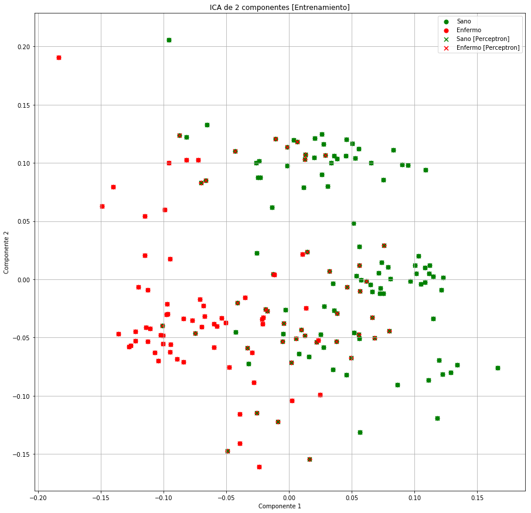

```python
from sklearn.decomposition import FastICA

transformador = FastICA(n_components=2, random_state=0)
X_transformado = transformador.fit_transform(Xstd_train)
X_transformado.shape

Entrenamiento = pd.DataFrame(data=X_transformado,columns=['Componente 1','Componente 2'])
Entrenamiento_Final = pd.concat([Entrenamiento,pd.Series(label_train,name='Enfermo')],axis=1)
fig = plt.figure(figsize=(15,15))
ax = fig.add_subplot(111)

ax.set_xlabel("Componente 1")
ax.set_ylabel("Componente 2")
ax.set_title("ICA de 2 componentes [Entrenamiento]")
targets = [0,1]
colores = ['g','r']
for target, color in zip(targets,colores):
    indice = Entrenamiento_Final['Enfermo'] == target
    ax.scatter(Entrenamiento_Final.loc[indice, 'Componente 1']
               , Entrenamiento_Final.loc[indice, 'Componente 2']
              , c = color
              , s = 50)

Perceptron = pd.DataFrame(data=X_transformado,columns=['Componente 1','Componente 2'])
Perceptron_Final = pd.concat([Entrenamiento,pd.Series(pred_train,name='Enfermo')],axis=1)
targets = [0,1]
colores = ['g','r']
for target, color in zip(targets,colores):
    indice = Perceptron_Final['Enfermo'] == target
    ax.scatter(Perceptron_Final.loc[indice, 'Componente 1']
               , Perceptron_Final.loc[indice, 'Componente 2']
              , c = color
              , s = 50
              ,marker = "x")
ax.legend(["Sano","Enfermo",'Sano [Perceptron]','Enfermo [Perceptron]'])
ax.grid()
plt.show()
```

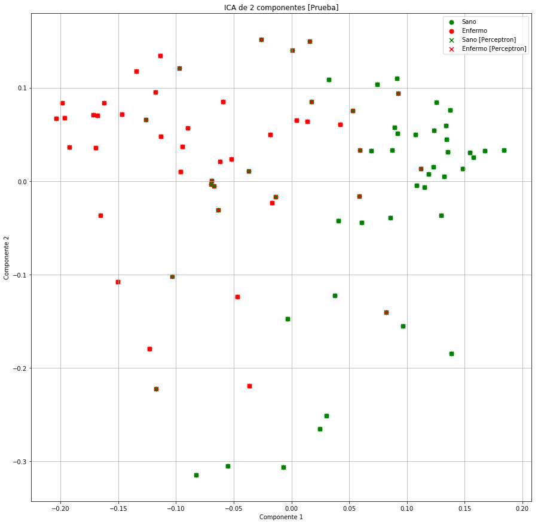

```python
transformador = FastICA(n_components=2, random_state=0)
X_pca_test = transformador.fit_transform(Xstd_test)

Test = pd.DataFrame(data=X_pca_test,columns=['Componente 1','Componente 2'])
Test_Final = pd.concat([Test,pd.Series(label_test,name='Enfermo')],axis=1)
fig = plt.figure(figsize=(15,15))
ax = fig.add_subplot(1,1,1)
ax.set_xlabel("Componente 1")
ax.set_ylabel("Componente 2")
ax.set_title("ICA de 2 componentes [Prueba]")
targets = [0,1]
colores = ['g','r']
for target, color in zip(targets,colores):
    indice = Test_Final['Enfermo'] == target
    ax.scatter(Test_Final.loc[indice, 'Componente 1']
               , Test_Final.loc[indice, 'Componente 2']
              , c = color
              , s = 50)

Perceptron = pd.DataFrame(data=X_pca_test,columns=['Componente 1','Componente 2'])
Perceptron_Final = pd.concat([Perceptron,pd.Series(pred_test,name='Enfermo')],axis=1)
targets = [0,1]
colores = ['g','r']
for target, color in zip(targets,colores):
    indice = Perceptron_Final['Enfermo'] == target
    ax.scatter(Perceptron_Final.loc[indice, 'Componente 1']
               , Perceptron_Final.loc[indice, 'Componente 2']
              , c = color
              , s = 50
              , marker = "x")
ax.legend(["Sano","Enfermo",'Sano [Perceptron]','Enfermo [Perceptron]'])
ax.grid()
plt.show()
```

La distribución de las clases es notoria, al igual que en PCA, pero la distribución es distinta así como la forma de la frontera (o la recta para ser más exactos)

### Análisis de las reducciones

Al usar una reducción de dimensionalidad obtendremos una pérdida de representación a como era el dataset original. Este fénomeno es esperable ya que estamos reduciendo el espacio de las componentes originales y relacionandolas unas con otras sin que estas así lo sean, dentro de las métricas de PCA tenemos su varianza de las componentes y el ruido, las cuales tiene los siguientes valores para los modelos de entrenamiento

```python
print("Varianza PCA:",varianza_PCA_train)
print("Ruido PCA:", ruido_PCA_train)
```

```
Varianza PCA: [0.19290252 0.10386805]
Ruido PCA: 0.7713515112120639
```

# Estimación de edad de personas